```python
import pandas as pd
import numpy as np
import matplotlib.pyplot as plt
from matplotlib.ticker import ScalarFormatter
from matplotlib import colors
from pandas import read_csv
```

# Uwagi Wstępne

Ze względu na bardzo małą ilość pokrywających się danych w tabeli orbits oraz tabeli impacts, praktycznie niemożliwe jest wyciąganie jakichkolwiek wniosków np na podstawie np.: osi orbity do ich ilości potencjalnych zderzeń z ziemią czy też jaki posiadają stopień w skali palermo itd. Pokrywa się dokładnie 5 asteroid miedzy jedną a drugą tabelką

# Konfiguracja

```python
#a)
#Your code:
d_orb = read_csv("./datasets/orbits.csv", encoding="UTF-8")
d_imp = read_csv("./datasets/impacts.csv", encoding="UTF-8")
d_orb.columns = [
    'nazwa_obiektu',
    'klasyfikacja_obiektu',
    'epoka_tdb',
    'polos_orbit_au',
    'ekscentrycznosc_orbity',
    'inklinacja_orbity_st',
    'argument_peryhelium_st',
    'dlugosc_wezla_st',
    'anomalia_srednia_st',
    'odleglosc_peryhelium_au',
    'odleglosc_aphelium_au',
    'okres_orbitalny_lata',
    'minimalna_odleglosc_przeciecia_orbit_au',
    'referencja_orbity',
    'magnituda_asteroidy'
]
d_imp.columns = [
    'nazwa_obiektu',
    'poczatek_okresu',
    'koniec_okresu',
    'mozliwe_uderzenia',
    'skum_prawdopodobienstwo_uderzenia',
    'predkosc_asteroidy',
    'magnituda_asteroidy',
    'srednica_asteroidy_km',
    'skumulowana_skala_palermo',
    'maksymalna_skala_palermo',
    'maksymalna_skala_turynu'
]

d_orb['nazwa_obiektu'] = d_orb['nazwa_obiektu'].str.replace('\xa0', ' ', regex=False)
d_orb.insert(2, "zagrozenie", value=False,allow_duplicates=False)
d_orb['zagrozenie'] = d_orb['klasyfikacja_obiektu'].str.extract('(Hazard)')
d_orb['zagrozenie'] = d_orb['zagrozenie'].notna()
d_orb.sample(10)
#Hint: read_csv(), head()
```

|  | nazwa_obiektu | klasyfikacja_obiektu | zagrozenie | epoka_tdb | polos_orbit_au | ekscentrycznosc_orbity | inklinacja_orbity_st | argument_peryhelium_st | dlugosc_wezla_st | anomalia_srednia_st | odleglosc_peryhelium_au | odleglosc_aphelium_au | okres_orbitalny_lata | minimalna_odleglosc_przeciecia_orbit_au | referencja_orbity | magnituda_asteroidy |
| --- | --- | --- | --- | --- | --- | --- | --- | --- | --- | --- | --- | --- | --- | --- | --- | --- |
| 13587 | (2016 AH66) | Amor Asteroid | False | 57395 | 1.3598 | 0.2132 | 4.6070 | 349.4623 | 84.2105 | 21.3529 | 1.0699 | 1.65 | 1.59 | 0.0857 | 3 | 25.9 |
| 309 | 65909 (1998 FH12) | Apollo Asteroid (Hazard) | True | 57800 | 1.0910 | 0.5398 | 3.5596 | 284.4527 | 108.6354 | 295.5340 | 0.5021 | 1.68 | 1.14 | 0.0129 | 78 | 19.2 |
| 4051 | (2005 GB34) | Apollo Asteroid | False | 57800 | 1.4139 | 0.2952 | 20.2913 | 161.6841 | 17.8254 | 29.8959 | 0.9965 | 1.83 | 1.68 | 0.0068 | 9 | 25.4 |
| 7163 | (2010 KP10) | Apollo Asteroid | False | 57800 | 1.1312 | 0.1660 | 16.1945 | 276.3602 | 233.3387 | 290.0898 | 0.9434 | 1.32 | 1.20 | 0.0610 | 39 | 23.4 |
| 10920 | (2014 HC192) | Apollo Asteroid | False | 56775 | 1.1594 | 0.2160 | 9.8857 | 280.2166 | 34.3710 | 287.0279 | 0.9090 | 1.41 | 1.25 | 0.0426 | 7 | 26.8 |
| 6990 | (2010 EK43) | Apollo Asteroid | False | 57800 | 1.3976 | 0.6536 | 7.8875 | 38.4682 | 18.4823 | 109.0924 | 0.4841 | 2.31 | 1.65 | 0.0765 | 16 | 21.6 |
| 3508 | (2003 UO25) | Apollo Asteroid | False | 57800 | 1.0165 | 0.2289 | 15.4749 | 28.5572 | 211.8759 | 132.8871 | 0.7838 | 1.25 | 1.02 | 0.1654 | 13 | 22.6 |
| 9530 | (2013 AB65) | Apollo Asteroid | False | 56306 | 1.8118 | 0.7497 | 2.4426 | 252.2610 | 113.8141 | 19.5713 | 0.4535 | 3.17 | 2.44 | 0.0020 | 4 | 27.6 |
| 5438 | (2007 XA23) | Apollo Asteroid | False | 57800 | 1.6064 | 0.3769 | 8.3259 | 62.6353 | 78.8907 | 155.4255 | 1.0010 | 2.21 | 2.04 | 0.0967 | 11 | 23.0 |
| 758 | 163412 (2002 RV25) | Amor Asteroid | False | 57800 | 1.9074 | 0.4508 | 34.4998 | 46.1262 | 18.1867 | 146.5561 | 1.0476 | 2.77 | 2.63 | 0.1481 | 62 | 17.3 |

```python
d_imp.head(1)
```

|  | nazwa_obiektu | poczatek_okresu | koniec_okresu | mozliwe_uderzenia | skum_prawdopodobienstwo_uderzenia | predkosc_asteroidy | magnituda_asteroidy | srednica_asteroidy_km | skumulowana_skala_palermo | maksymalna_skala_palermo | maksymalna_skala_turynu |
| --- | --- | --- | --- | --- | --- | --- | --- | --- | --- | --- | --- |
| 0 | 2006 WP1 | 2017 | 2017 | 1 | 5.200000e-09 | 17.77 | 28.3 | 0.007 | -8.31 | -8.31 | 0 |

```python
d_orb.head(1)
```

|  | nazwa_obiektu | klasyfikacja_obiektu | zagrozenie | epoka_tdb | polos_orbit_au | ekscentrycznosc_orbity | inklinacja_orbity_st | argument_peryhelium_st | dlugosc_wezla_st | anomalia_srednia_st | odleglosc_peryhelium_au | odleglosc_aphelium_au | okres_orbitalny_lata | minimalna_odleglosc_przeciecia_orbit_au | referencja_orbity | magnituda_asteroidy |
| --- | --- | --- | --- | --- | --- | --- | --- | --- | --- | --- | --- | --- | --- | --- | --- | --- |
| 0 | 433 Eros | Amor Asteroid | False | 57800 | 1.4579 | 0.2226 | 10.8277 | 178.805 | 304.3265 | 319.3111 | 1.1335 | 1.78 | 1.76 | 0.1492 | 598 | 11.16 |

```python
#b)
d_orb_categorical =['nazwa_obiektu',
                    'klasyfikacja_obiektu','referencja_orbity']
d_orb_numerical = ['epoka_tdb',
                   'polos_orbit_au',
                   'ekscentrycznosc_orbity',
                   'inklinacja_orbity_st',
                   'argument_peryhelium_st',
                   'dlugosc_wezla_st',
                   'anomalia_srednia_st',
                   'odleglosc_peryhelium_au',
                   'odleglosc_aphelium_au',
                   'okres_orbitalny_lata',
                   'minimalna_odleglosc_przeciecia_orbit_au',
                   'magnituda_asteroidy']

d_imp_categorical = ['nazwa_obiektu','skumulowana_skala_palermo',
                     'maksymalna_skala_palermo',
                     'maksymalna_skala_turynu']
d_imp_numerical_ = ['poczatek_okresu',
                    'koniec_okresu',
                    'mozliwe_uderzenia',
                    'skum_prawdopodobienstwo_uderzenia',
                    'predkosc_asteroidy',
                    'magnituda_asteroidy',
                    'srednica_asteroidy_km',
                    ]
```

```python
#c)
#Your code:
d_orb.describe()
#Hint: Function describe()
```

|  | epoka_tdb | polos_orbit_au | ekscentrycznosc_orbity | inklinacja_orbity_st | argument_peryhelium_st | dlugosc_wezla_st | anomalia_srednia_st | odleglosc_peryhelium_au | odleglosc_aphelium_au | okres_orbitalny_lata | minimalna_odleglosc_przeciecia_orbit_au | referencja_orbity | magnituda_asteroidy |
| --- | --- | --- | --- | --- | --- | --- | --- | --- | --- | --- | --- | --- | --- |
| count | 15635.000000 | 15635.000000 | 15635.000000 | 15635.000000 | 15635.00000 | 15635.000000 | 15635.000000 | 15635.000000 | 15635.000000 | 15635.000000 | 15635.000000 | 15635.000000 | 15634.000000 |
| mean | 57365.394947 | 1.781002 | 0.449694 | 12.941175 | 181.50956 | 172.672154 | 172.834863 | 0.914912 | 2.647087 | 2.473406 | 0.101884 | 21.885257 | 22.286336 |
| std | 1167.238040 | 0.603229 | 0.176000 | 11.303231 | 103.86248 | 103.384143 | 116.123065 | 0.240309 | 1.142659 | 1.517588 | 0.105937 | 33.632091 | 3.016002 |
| min | 44221.000000 | 0.547600 | 0.004400 | 0.014700 | 0.00810 | 0.007000 | 0.003100 | 0.070700 | 0.800000 | 0.410000 | 0.000000 | 1.000000 | 9.450000 |
| 25% | 57800.000000 | 1.323600 | 0.322700 | 4.762450 | 92.43535 | 82.241950 | 62.040250 | 0.776750 | 1.740000 | 1.520000 | 0.018700 | 6.000000 | 19.900000 |
| 50% | 57800.000000 | 1.735500 | 0.462900 | 9.197400 | 183.31780 | 172.173400 | 167.750200 | 0.965800 | 2.520000 | 2.290000 | 0.062000 | 11.000000 | 22.200000 |
| 75% | 57800.000000 | 2.208650 | 0.572900 | 18.510900 | 270.91745 | 253.660050 | 281.443100 | 1.080300 | 3.420000 | 3.280000 | 0.159150 | 23.000000 | 24.600000 |
| max | 57800.000000 | 21.395400 | 0.969500 | 154.375100 | 359.99420 | 359.998100 | 359.998200 | 1.300000 | 41.540000 | 98.970000 | 0.706900 | 635.000000 | 33.200000 |

```python
d_imp.describe()
```

|  | poczatek_okresu | koniec_okresu | mozliwe_uderzenia | skum_prawdopodobienstwo_uderzenia | predkosc_asteroidy | magnituda_asteroidy | srednica_asteroidy_km | skumulowana_skala_palermo | maksymalna_skala_palermo |
| --- | --- | --- | --- | --- | --- | --- | --- | --- | --- |
| count | 683.000000 | 683.000000 | 683.000000 | 6.830000e+02 | 683.000000 | 683.000000 | 683.000000 | 683.000000 | 683.000000 |
| mean | 2062.573939 | 2099.680820 | 43.348463 | 1.539476e-04 | 11.462577 | 26.158272 | 0.049378 | -6.511552 | -6.804012 |
| std | 43.501694 | 37.594698 | 113.773280 | 2.519607e-03 | 6.067772 | 2.388296 | 0.156403 | 1.509189 | 1.476135 |
| min | 2017.000000 | 2017.000000 | 1.000000 | 1.100000e-10 | 0.340000 | 15.600000 | 0.002000 | -10.980000 | -11.000000 |
| 25% | 2034.000000 | 2090.000000 | 2.000000 | 1.100000e-07 | 7.240000 | 25.000000 | 0.010000 | -7.490000 | -7.790000 |
| 50% | 2061.000000 | 2109.000000 | 6.000000 | 1.700000e-06 | 10.500000 | 26.400000 | 0.017000 | -6.460000 | -6.790000 |
| 75% | 2085.000000 | 2114.000000 | 29.000000 | 1.550000e-05 | 14.810000 | 27.800000 | 0.033000 | -5.490000 | -5.865000 |
| max | 2880.000000 | 2880.000000 | 1144.000000 | 6.500000e-02 | 39.470000 | 31.600000 | 2.579000 | -1.420000 | -1.420000 |

# Analiza orbit asteroid

Używając wykresów, przedstaw:

*) Podstawowe statystyki zbiorcze zbioru orbit

a) Ilość potencjalnie niebezpiecznych obiektów, które krąża wokół ziemi

b) Pokaż związek między szybkością asteoroidy oraz magnitudą, a tym czy jest niebezpieczna

c) Stwórz macierz korelacji dla każdej zmiennej

```python
# *)
d_orb.describe()
```

|  | epoka_tdb | polos_orbit_au | ekscentrycznosc_orbity | inklinacja_orbity_st | argument_peryhelium_st | dlugosc_wezla_st | anomalia_srednia_st | odleglosc_peryhelium_au | odleglosc_aphelium_au | okres_orbitalny_lata | minimalna_odleglosc_przeciecia_orbit_au | referencja_orbity | magnituda_asteroidy |
| --- | --- | --- | --- | --- | --- | --- | --- | --- | --- | --- | --- | --- | --- |
| count | 15635.000000 | 15635.000000 | 15635.000000 | 15635.000000 | 15635.00000 | 15635.000000 | 15635.000000 | 15635.000000 | 15635.000000 | 15635.000000 | 15635.000000 | 15635.000000 | 15634.000000 |
| mean | 57365.394947 | 1.781002 | 0.449694 | 12.941175 | 181.50956 | 172.672154 | 172.834863 | 0.914912 | 2.647087 | 2.473406 | 0.101884 | 21.885257 | 22.286336 |
| std | 1167.238040 | 0.603229 | 0.176000 | 11.303231 | 103.86248 | 103.384143 | 116.123065 | 0.240309 | 1.142659 | 1.517588 | 0.105937 | 33.632091 | 3.016002 |
| min | 44221.000000 | 0.547600 | 0.004400 | 0.014700 | 0.00810 | 0.007000 | 0.003100 | 0.070700 | 0.800000 | 0.410000 | 0.000000 | 1.000000 | 9.450000 |
| 25% | 57800.000000 | 1.323600 | 0.322700 | 4.762450 | 92.43535 | 82.241950 | 62.040250 | 0.776750 | 1.740000 | 1.520000 | 0.018700 | 6.000000 | 19.900000 |
| 50% | 57800.000000 | 1.735500 | 0.462900 | 9.197400 | 183.31780 | 172.173400 | 167.750200 | 0.965800 | 2.520000 | 2.290000 | 0.062000 | 11.000000 | 22.200000 |
| 75% | 57800.000000 | 2.208650 | 0.572900 | 18.510900 | 270.91745 | 253.660050 | 281.443100 | 1.080300 | 3.420000 | 3.280000 | 0.159150 | 23.000000 | 24.600000 |
| max | 57800.000000 | 21.395400 | 0.969500 | 154.375100 | 359.99420 | 359.998100 | 359.998200 | 1.300000 | 41.540000 | 98.970000 | 0.706900 | 635.000000 | 33.200000 |

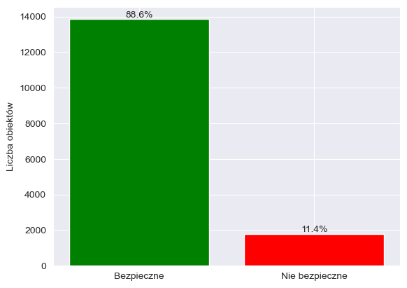

```python
# Zliczanie ilości zagrożeń i bezpieczeństwa
counts = d_orb['zagrozenie'].value_counts()
total = counts.sum()

# Obliczanie procentów
percentages = counts / total * 100

# Tworzenie wykresu
fig, ax = plt.subplots()
bars = ax.bar(['Bezpieczne','Nie bezpieczne'], counts.values, color=['green','red'])

# Dodawanie procentów nad słupkami
for bar, percentage in zip(bars, percentages):
    ax.text(bar.get_x() + bar.get_width() / 2, bar.get_height(), f'{percentage:.1f}%',
            ha='center', va='bottom')

# Dodanie tytułu i etykiet osi
ax.set_ylabel('Liczba obiektów')

# Wyświetlenie wykresu
plt.show()
```

```
([], [])
```

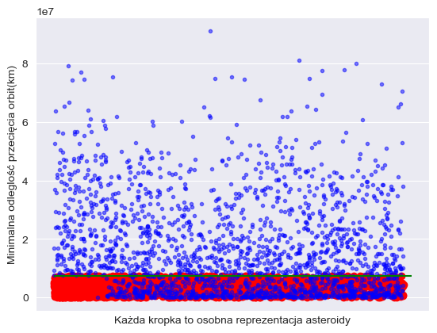

```python
#b)
#Your code:
danger = d_orb.loc[d_orb['zagrozenie'] == True]
safe = d_orb.loc[d_orb['zagrozenie'] == False]
plt.plot(danger['minimalna_odleglosc_przeciecia_orbit_au']*149597870.7, linestyle='none', marker='o', c='red')
plt.plot(safe['minimalna_odleglosc_przeciecia_orbit_au'].sample(2000)*149597870.7, linestyle='none', marker='.', c='blue', alpha=0.5)
plt.ylabel("Minimalna odleglość przecięcia orbit(km)")
plt.xlabel("Każda kropka to osobna reprezentacja asteroidy")
plt.hlines(0.05*149597870.7,0,16000, colors='green')
plt.xticks([])
```

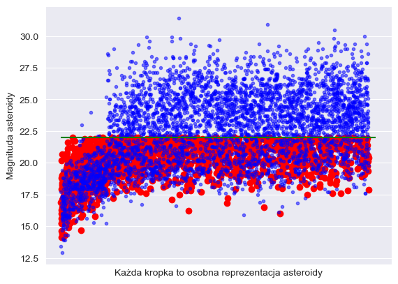

```python
# b)
label = 'magnituda_asteroidy'
plt.plot(danger[label], linestyle='none', marker='o', c='red')
plt.plot(safe[label].sample(4000), linestyle='none', marker='.', c='blue', alpha=0.5)
plt.ylabel("Magnituda asteroidy")
plt.xlabel("Każda kropka to osobna reprezentacja asteroidy")
plt.hlines(22,0,16000, colors='green')
plt.xticks([])
plt.show()
```

> *Komentarz:* Podobnie dzieję się z magnitudą, nie jestem w stanie wyjaśnić dlaczego obiekty niebezpieczne mają ją zawsze mniejszą od 22, na wykresie zaznaczona granica

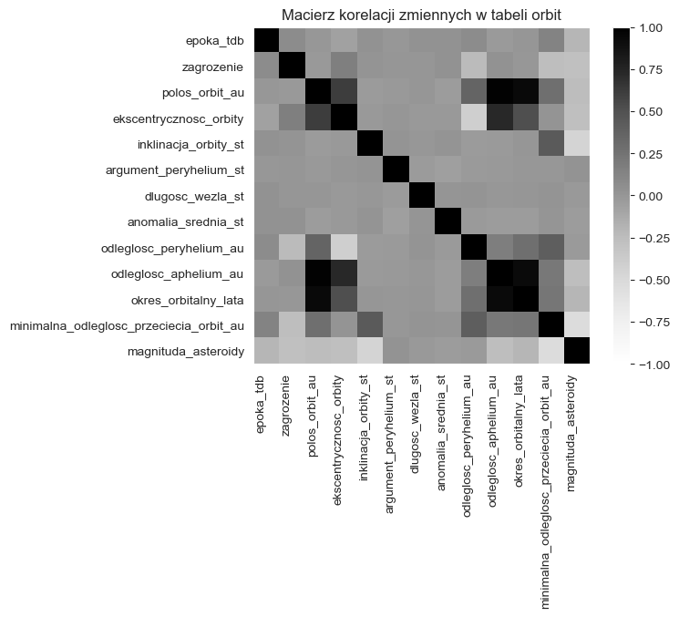

```python
# c)
labels_orb = ['epoka_tdb', 'zagrozenie', 'polos_orbit_au', 'ekscentrycznosc_orbity', 'inklinacja_orbity_st', 'argument_peryhelium_st', 'dlugosc_wezla_st', 'anomalia_srednia_st', 'odleglosc_peryhelium_au', 'odleglosc_aphelium_au', 'okres_orbitalny_lata', 'minimalna_odleglosc_przeciecia_orbit_au', 'magnituda_asteroidy']
corr_orb = d_orb[labels_orb].corr()

fig, ax = plt.subplots()

divnorm = colors.TwoSlopeNorm(vmin=-1, vcenter=0, vmax=1)
cax = ax.imshow(corr_orb, cmap='Greys', interpolation='none', norm=divnorm)

ax.set_xticks(np.arange(len(labels_orb)))
ax.set_yticks(np.arange(len(labels_orb)))
ax.set_xticklabels(labels_orb)
ax.set_yticklabels(labels_orb)

plt.title("Macierz korelacji zmiennych w tabeli orbit")
plt.colorbar(cax)  # Pasek kolorów
plt.xticks(rotation=90, ha="right")
plt.grid(False)
plt.show()
```

# Analiza uderzeń

*) Podstawowe statystyki zbiorcze

a) Zobaczmy korelacje każdej zmiennej ze sobą, na wykresie oraz w tabeli

b) Pokaż związek pomiędzy prawdopodobieństwem skumulowanym, a potencjalnymi scenariuszami uderzeń

```python
# *)
d_imp.describe()
```

|  | poczatek_okresu | koniec_okresu | mozliwe_uderzenia | skum_prawdopodobienstwo_uderzenia | predkosc_asteroidy | magnituda_asteroidy | srednica_asteroidy_km | skumulowana_skala_palermo | maksymalna_skala_palermo |
| --- | --- | --- | --- | --- | --- | --- | --- | --- | --- |
| count | 683.000000 | 683.000000 | 683.000000 | 6.830000e+02 | 683.000000 | 683.000000 | 683.000000 | 683.000000 | 683.000000 |
| mean | 2062.573939 | 2099.680820 | 43.348463 | 1.539476e-04 | 11.462577 | 26.158272 | 0.049378 | -6.511552 | -6.804012 |
| std | 43.501694 | 37.594698 | 113.773280 | 2.519607e-03 | 6.067772 | 2.388296 | 0.156403 | 1.509189 | 1.476135 |
| min | 2017.000000 | 2017.000000 | 1.000000 | 1.100000e-10 | 0.340000 | 15.600000 | 0.002000 | -10.980000 | -11.000000 |
| 25% | 2034.000000 | 2090.000000 | 2.000000 | 1.100000e-07 | 7.240000 | 25.000000 | 0.010000 | -7.490000 | -7.790000 |
| 50% | 2061.000000 | 2109.000000 | 6.000000 | 1.700000e-06 | 10.500000 | 26.400000 | 0.017000 | -6.460000 | -6.790000 |
| 75% | 2085.000000 | 2114.000000 | 29.000000 | 1.550000e-05 | 14.810000 | 27.800000 | 0.033000 | -5.490000 | -5.865000 |
| max | 2880.000000 | 2880.000000 | 1144.000000 | 6.500000e-02 | 39.470000 | 31.600000 | 2.579000 | -1.420000 | -1.420000 |

```python
# a)
labels_imp = ['poczatek_okresu', 'koniec_okresu', 'mozliwe_uderzenia','skum_prawdopodobienstwo_uderzenia', 'predkosc_asteroidy','magnituda_asteroidy', 'srednica_asteroidy_km', 'skumulowana_skala_palermo', 'maksymalna_skala_palermo']
corr_imp = d_imp[labels_imp].corr()
d_imp[labels_imp].corr()
```

|  | poczatek_okresu | koniec_okresu | mozliwe_uderzenia | skum_prawdopodobienstwo_uderzenia | predkosc_asteroidy | magnituda_asteroidy | srednica_asteroidy_km | skumulowana_skala_palermo | maksymalna_skala_palermo |
| --- | --- | --- | --- | --- | --- | --- | --- | --- | --- |
| poczatek_okresu | 1.000000 | 0.679122 | -0.278767 | 0.032182 | -0.004627 | -0.058755 | 0.155077 | -0.058681 | 0.006123 |
| koniec_okresu | 0.679122 | 1.000000 | 0.130901 | 0.024318 | -0.155407 | -0.067195 | 0.236800 | 0.195462 | 0.152466 |
| mozliwe_uderzenia | -0.278767 | 0.130901 | 1.000000 | 0.007800 | -0.136847 | 0.073852 | -0.034076 | 0.168304 | 0.050068 |
| skum_prawdopodobienstwo_uderzenia | 0.032182 | 0.024318 | 0.007800 | 1.000000 | -0.059637 | 0.047506 | -0.013629 | 0.115400 | 0.126261 |
| predkosc_asteroidy | -0.004627 | -0.155407 | -0.136847 | -0.059637 | 1.000000 | -0.332128 | 0.174876 | 0.073115 | 0.114209 |
| magnituda_asteroidy | -0.058755 | -0.067195 | 0.073852 | 0.047506 | -0.332128 | 1.000000 | -0.612503 | -0.390285 | -0.410850 |
| srednica_asteroidy_km | 0.155077 | 0.236800 | -0.034076 | -0.013629 | 0.174876 | -0.612503 | 1.000000 | 0.267590 | 0.278695 |
| skumulowana_skala_palermo | -0.058681 | 0.195462 | 0.168304 | 0.115400 | 0.073115 | -0.390285 | 0.267590 | 1.000000 | 0.978823 |
| maksymalna_skala_palermo | 0.006123 | 0.152466 | 0.050068 | 0.126261 | 0.114209 | -0.410850 | 0.278695 | 0.978823 | 1.000000 |

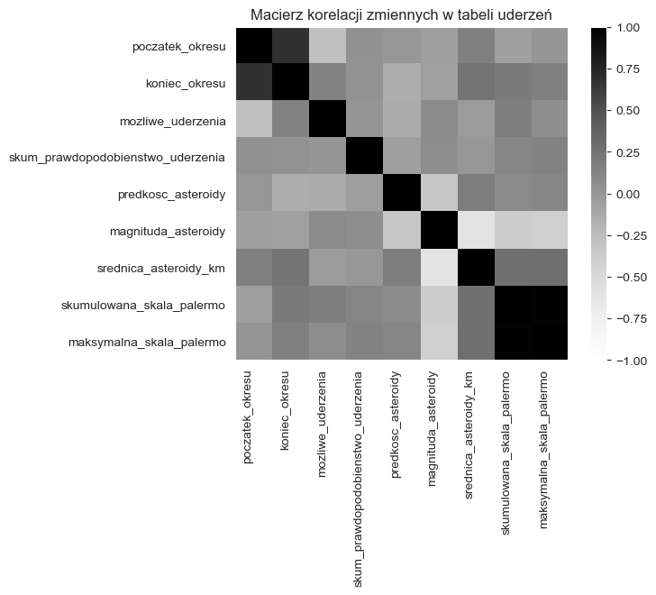

```python
fig, ax = plt.subplots()

divnorm = colors.TwoSlopeNorm(vmin=-1, vcenter=0, vmax=1)
cax = ax.imshow(corr_imp, cmap='Greys', interpolation='none', norm=divnorm)

ax.set_xticks(np.arange(len(labels_imp)))
ax.set_yticks(np.arange(len(labels_imp)))
ax.set_xticklabels(labels_imp)
ax.set_yticklabels(labels_imp)

plt.title("Macierz korelacji zmiennych w tabeli uderzeń")
plt.colorbar(cax)  # Pasek kolorów
plt.xticks(rotation=90, ha="right")
plt.grid(False)
plt.show()
```

> *Komentarz:* Myśle, że jest tutaj parę istotnych rzeczy, które warto skomentować, a niektóre z nich później pokażę na wykresach, jest tutaj trochę takich oczywistych zależności jak to, że magnituda asteroidy zależy od jej średnicy czy też wielkości, ale są też mniej oczywiste korelacje, takie jak fakt, że ilość scenariuszy uderzeń koreluje z początkiem okresu w jakim potencjalnie mogą się zdarzyć.

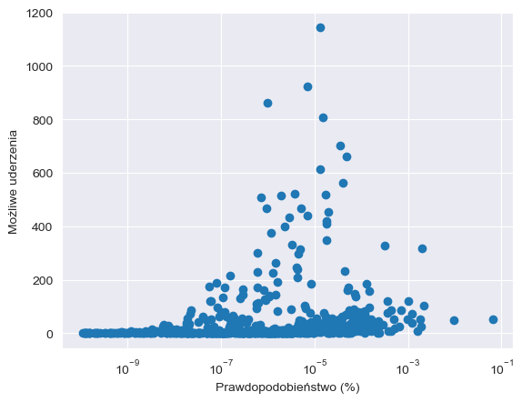

```python
#b)
#Your code:
plt.scatter(d_imp['skum_prawdopodobienstwo_uderzenia'], d_imp['mozliwe_uderzenia'])
plt.xscale('log')
plt.ylabel('Możliwe uderzenia')
plt.xlabel('Prawdopodobieństwo (%)')
```

> *Komentarz:* To co jest tutaj istotne apropo skomentowania, to to,że nie zawsze najwyższe prawdopodobieństwo wiąże się z najwiekszą ilością potencjalnych scenariuszy uderzeń. Nie wiem dokładnie skąd to się bierze, ale przypuszczam, że im bardziej coś prawdopodobne, to tym więcej mamy danych i możemy dokładnej określić potencjalną sytuację. Jeśli zaś za mało mamy danych i zachowaniu asteroidy, to tym mniej potencjalnych zdarzeń jesteśmy w stanie ułożyc. Oczywiście środek świadczy o tym, że mamy trochę danych i nie jesteśmy pewni co do zachowania, więc wymyślamy na podstawie jakiś danych dużo możliwych scenariuszy. Kreśli nam się tutaj coś na gausowskiego rozkładu normalnego

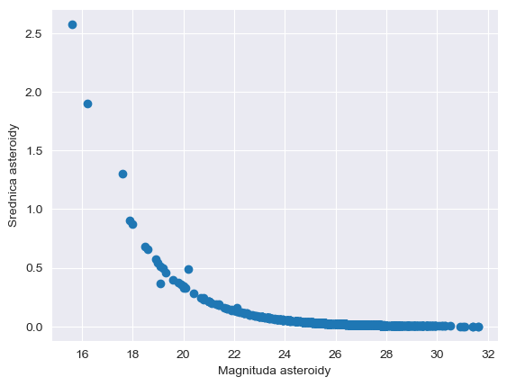

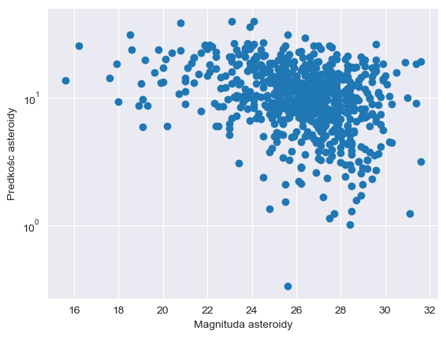

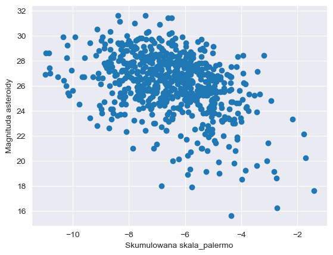

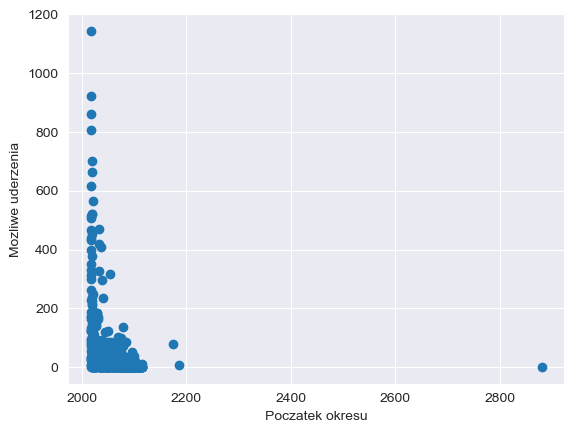

```python
#c)
fig1 = plt.subplot()
plt.scatter(d_imp['magnituda_asteroidy'], d_imp['srednica_asteroidy_km'])
plt.xlabel('Magnituda asteroidy')
plt.ylabel('Srednica asteroidy')
plt.show()

fig2 = plt.subplot()
plt.scatter(d_imp['magnituda_asteroidy'], d_imp['predkosc_asteroidy'])
plt.xlabel('Magnituda asteroidy')
plt.ylabel('Predkośc asteroidy')
plt.yscale('log')
plt.show()

fig3 = plt.subplot()
plt.scatter(d_imp['skumulowana_skala_palermo'], d_imp['magnituda_asteroidy'])
plt.ylabel('Magnituda asteroidy')
plt.xlabel('Skumulowana skala_palermo')
plt.show()

fig4 = plt.subplot()
plt.scatter(d_imp['poczatek_okresu'], d_imp['mozliwe_uderzenia'])
plt.xscale('log')
plt.ylabel('Mozliwe uderzenia')
plt.xlabel('Poczatek okresu')
plt.xscale('linear')
plt.show()
```

> *Komentarz:* Postaram się trochę skomentować każdy z tych wykresów, na pierwszym gdzie mamy zależność magnitudy oraz średnicy, widzimy eksponecjalny spadek, na następnym wykresie widzimy słabą korelację tych zmiennych, ale jednak wszystko widzimy pewnego rodzaju eksponecjalny spadek. Na kolejnym widzimy liniowy spadek, pokazuje to jak skala palermo klasyfikuje obiekty, jeżeli są one dużej magnitudy, to według skali nie stanowią niebezpieczeństwa, ale im ich magnituda mniejsza, tym groźniejsze się stają. Na czwartym ostatnim wyrkesie widzimy, fakt, że przy latach około 2017 jest o wiele więcej mozliwych scenariuszy zderzeń asteroid z ziemią. Im dalej w czasie idziemy tym mniej mamy scenariuszy(dość logiczne)

## Obiekty wspólne

Mamy 5 obiektów, które znajduja się w obydwu datasetach, przedstawię teraz ich dane na wykresach. Tu jest dość ciekawa sprawa, albowiem, nie wszystkie obiekty tutaj są klasyfikowane jako niebezpieczne ( (Hazard) ) w tabeli orbit

```python
# Filtracja tylko wierszy zawierających nawiasy
help = d_imp[d_imp['nazwa_obiektu'].str.contains(r'\(.*\)')]
help.loc[:,'nazwa_obiektu'] = help['nazwa_obiektu'].str.replace(r'\(.*\)', '', regex=True).str.strip()
d_all = pd.concat([pd.merge(help, d_orb.drop('magnituda_asteroidy', axis=1), on='nazwa_obiektu'),pd.merge(d_imp,d_orb.drop('magnituda_asteroidy', axis=1), on='nazwa_obiektu')])
d_all.describe()
```

|  | poczatek_okresu | koniec_okresu | mozliwe_uderzenia | skum_prawdopodobienstwo_uderzenia | predkosc_asteroidy | magnituda_asteroidy | srednica_asteroidy_km | skumulowana_skala_palermo | maksymalna_skala_palermo | epoka_tdb | ... | ekscentrycznosc_orbity | inklinacja_orbity_st | argument_peryhelium_st | dlugosc_wezla_st | anomalia_srednia_st | odleglosc_peryhelium_au | odleglosc_aphelium_au | okres_orbitalny_lata | minimalna_odleglosc_przeciecia_orbit_au | referencja_orbity |
| --- | --- | --- | --- | --- | --- | --- | --- | --- | --- | --- | --- | --- | --- | --- | --- | --- | --- | --- | --- | --- | --- |
| count | 5.000000 | 5.000000 | 5.000000 | 5.000000 | 5.000000 | 5.000000 | 5.000000 | 5.000000 | 5.000000 | 5.000000 | ... | 5.000000 | 5.000000 | 5.000000 | 5.00000 | 5.000000 | 5.000000 | 5.000000 | 5.000000 | 5.000000 | 5.000000 |
| mean | 2280.200000 | 2296.800000 | 20.000000 | 0.000424 | 9.742000 | 20.640000 | 0.474000 | -2.486000 | -2.638000 | 55916.400000 | ... | 0.319700 | 6.335480 | 192.813600 | 168.24730 | 138.403540 | 0.780540 | 1.604000 | 1.324000 | 0.009600 | 108.800000 |
| std | 339.297362 | 329.462744 | 32.718496 | 0.000674 | 4.843725 | 2.579341 | 0.492879 | 1.342844 | 1.278034 | 1259.249896 | ... | 0.164886 | 3.672691 | 92.966057 | 157.86216 | 106.903943 | 0.119514 | 0.584021 | 0.514471 | 0.017247 | 61.108101 |
| min | 2060.000000 | 2102.000000 | 1.000000 | 0.000009 | 5.850000 | 17.600000 | 0.050000 | -4.690000 | -4.690000 | 54441.000000 | ... | 0.191100 | 3.137000 | 66.223100 | 2.06090 | 27.060300 | 0.589600 | 1.100000 | 0.890000 | 0.000700 | 31.000000 |
| 25% | 2101.000000 | 2105.000000 | 2.000000 | 0.000019 | 5.990000 | 19.100000 | 0.160000 | -2.830000 | -2.930000 | 55394.000000 | ... | 0.203400 | 3.331300 | 126.393600 | 9.55810 | 65.446100 | 0.746100 | 1.260000 | 1.070000 | 0.001200 | 87.000000 |
| 50% | 2175.000000 | 2198.000000 | 7.000000 | 0.000120 | 6.900000 | 20.200000 | 0.370000 | -1.780000 | -2.320000 | 55562.000000 | ... | 0.203700 | 6.034900 | 224.535400 | 204.45720 | 101.703900 | 0.833100 | 1.360000 | 1.200000 | 0.002500 | 92.000000 |
| 75% | 2185.000000 | 2199.000000 | 12.000000 | 0.000370 | 14.100000 | 22.100000 | 0.490000 | -1.710000 | -1.830000 | 56385.000000 | ... | 0.492900 | 6.992600 | 265.689900 | 268.38420 | 215.540000 | 0.837000 | 1.740000 | 1.250000 | 0.003200 | 141.000000 |
| max | 2880.000000 | 2880.000000 | 78.000000 | 0.001600 | 15.870000 | 24.200000 | 1.300000 | -1.420000 | -1.420000 | 57800.000000 | ... | 0.507400 | 12.181600 | 281.226000 | 356.77610 | 282.267400 | 0.896900 | 2.560000 | 2.210000 | 0.040400 | 193.000000 |

8 rows × 21 columns

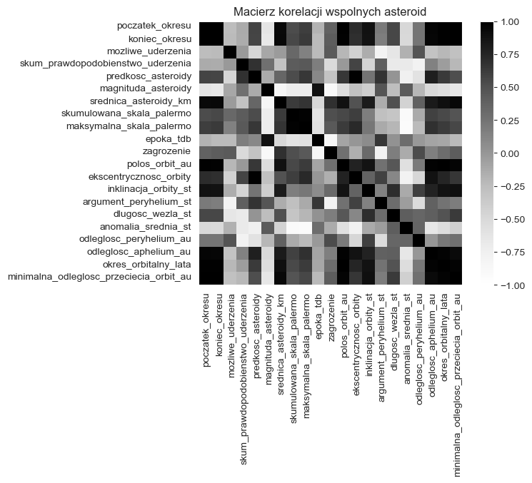

```python
#a)
labels_all = ['poczatek_okresu', 'koniec_okresu', 'mozliwe_uderzenia','skum_prawdopodobienstwo_uderzenia', 'predkosc_asteroidy','magnituda_asteroidy', 'srednica_asteroidy_km', 'skumulowana_skala_palermo', 'maksymalna_skala_palermo', 'epoka_tdb', 'zagrozenie', 'polos_orbit_au', 'ekscentrycznosc_orbity', 'inklinacja_orbity_st', 'argument_peryhelium_st', 'dlugosc_wezla_st', 'anomalia_srednia_st', 'odleglosc_peryhelium_au', 'odleglosc_aphelium_au', 'okres_orbitalny_lata', 'minimalna_odleglosc_przeciecia_orbit_au']
fig, ax = plt.subplots()

divnorm = colors.TwoSlopeNorm(vmin=-1, vcenter=0, vmax=1)
cax = ax.imshow(d_all[labels_all].corr(), cmap='Greys', interpolation='none', norm=divnorm)

ax.set_xticks(np.arange(len(labels_all))+0.5)
ax.set_yticks(np.arange(len(labels_all))-0.2)
ax.set_xticklabels(labels_all)
ax.set_yticklabels(labels_all)

plt.title("Macierz korelacji wspolnych asteroid")
plt.colorbar(cax)  # Pasek kolorów
plt.xticks(rotation=90, ha="right")
plt.grid(False)
plt.show()

#Hint: pandas.DataFrame.loc
```

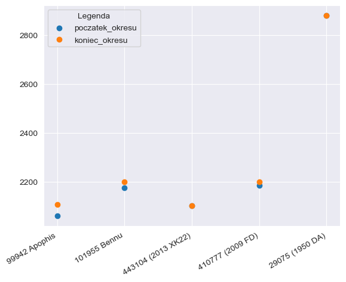

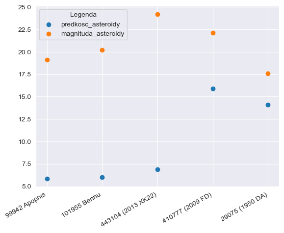

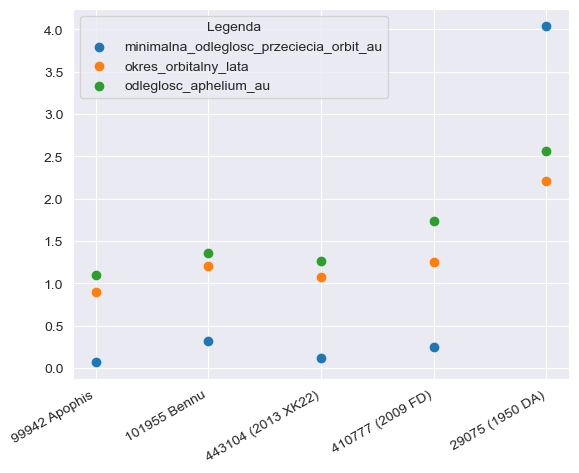

```python
#b)
#Your code:b
labels1 = ['poczatek_okresu', 'koniec_okresu']
for x in labels1:
    plt.scatter(d_all['nazwa_obiektu'],d_all[x])
plt.xticks(rotation=30, ha="right")
plt.legend(labels1,title="Legenda")
plt.show()

labels2 = ['predkosc_asteroidy', 'magnituda_asteroidy']
for x in labels2:
    plt.scatter(d_all['nazwa_obiektu'],d_all[x])
plt.xticks(rotation=30, ha="right")
plt.legend(labels2,title="Legenda")
plt.show()

labels3 = ['minimalna_odleglosc_przeciecia_orbit_au', 'okres_orbitalny_lata', 'odleglosc_aphelium_au']
for x in labels3:
    if x=='minimalna_odleglosc_przeciecia_orbit_au':
        plt.scatter(d_all['nazwa_obiektu'],d_all[x]*100)
    else:
        plt.scatter(d_all['nazwa_obiektu'],d_all[x])
plt.xticks(rotation=30, ha="right")
plt.legend(labels3,title="Legenda")
plt.show()

# exclude_labels = labels1 + labels2 + labels3
# for x in labels_all:
#     if x not in exclude_labels:
#         plt.scatter(d_all['nazwa_obiektu'],d_all[x])
#         plt.xlabel("Obiekt")
#         plt.ylabel(x)
#         plt.xticks(rotation=30, ha="right")
#         plt.show()
```

> *Komentarz:* Skomentuje troche co tutaj się dzieje, albowiem tak jak wspominałem, mamy za mało danych aby wyciagać jakiekolwiek wnioski, ale są pewne zależności, które warto pokazać, w zasadzie pokazywałem je już wcześniej, ale tutaj jednostkowo też je widać, jak związek pomiedzy magnitudą a predkością asteroidy. Są to jednak dane warte pokazania. Nie ma również sensu brać pod uwagę macierzy koleracji, ale została wykonana, żeby móc potencjalnie rzucić na nią okiem, ale nie można również wyciagać z niej żadnych wniosków. Mogło by się okazać, że jeżeli mielibyśmy więcej danych to wyżej widniejące korelację, przestały by istnieć. Istotna uwaga jest taka, że dane odnośnie minimalnej odległości przecięcia orbit, zostały przemnożone przez 100, aby pokazać podobne zachowanie danych.

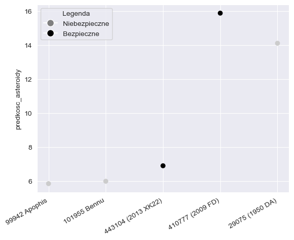

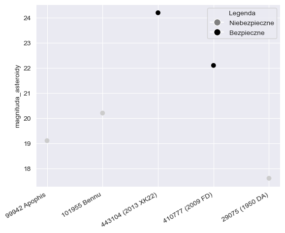

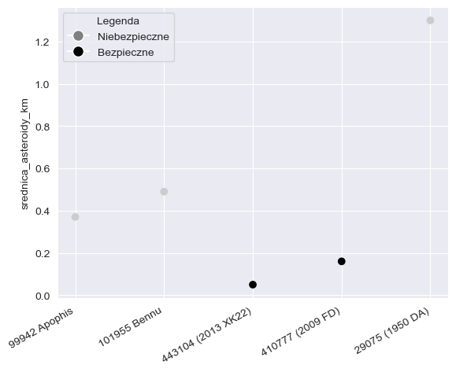

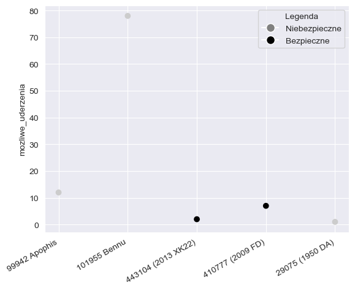

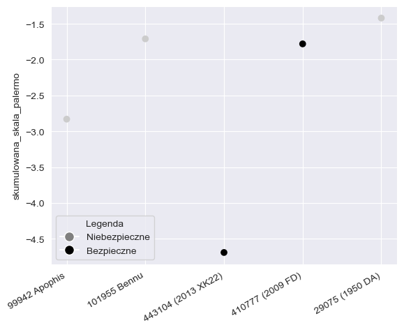

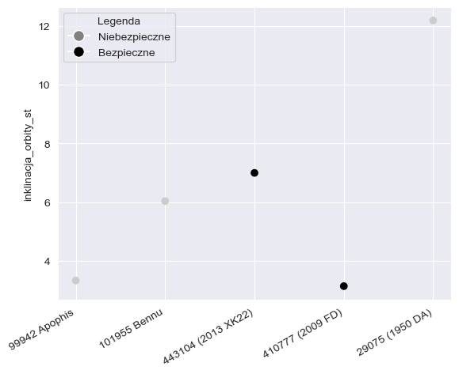

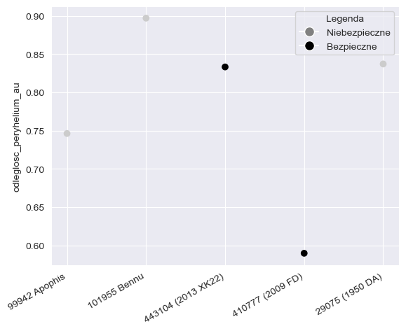

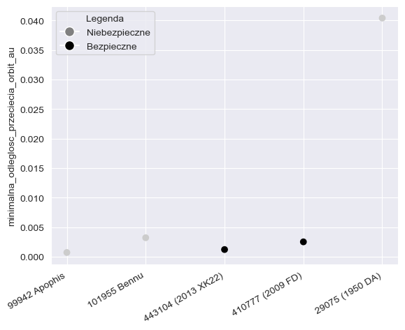

```python
labels4 = ['predkosc_asteroidy', 'magnituda_asteroidy', 'srednica_asteroidy_km', 'mozliwe_uderzenia', 'skumulowana_skala_palermo', 'inklinacja_orbity_st', 'odleglosc_peryhelium_au', 'minimalna_odleglosc_przeciecia_orbit_au']
legend_elements = [
    plt.Line2D([0], [0], marker='o', color='w', markerfacecolor='grey', markersize=10, label='Niebezpieczne'),
    plt.Line2D([0], [0], marker='o', color='w', markerfacecolor='black', markersize=10, label='Bezpieczne')
]
for x in labels4:
    plt.scatter(d_all['nazwa_obiektu'],d_all[x], cmap='nipy_spectral', c=d_all['zagrozenie'])
    plt.legend(handles=legend_elements,title="Legenda")
    plt.ylabel(x)
    plt.xticks(rotation=30, ha="right")
    plt.show()
```

> *Komentarz:* To, co tutaj chciałem pokazać, to dane, które mogą jakoś mówić, w jaki sposób asteroidy są klasyfikowane jako niebezpieczne bądź bezpieczne, ale z uwzględnieniem wszystkich danych, a nie tak jak poprzednio tylko jednej tabeli orbit. Tutaj widzimy, że rzeczywiście wpływa na to minimalna odległość przecięcia orbit (chociaż niekoniecznie musi, niektóre obiekty mają mniejszą odległość przecięcia, a są klasyfikowane jako niebezpieczne). Podobną do poprzedniego przykładu zależność, możemy obserwować w możliwych uderzeniach czy średnicy asteroidy. Magnituda o dziwo im mniejsza tym, bardziej prawdopodobne, że zostanie zakwalifikowany jako niebezpieczny.